#### Attrition by Job Level

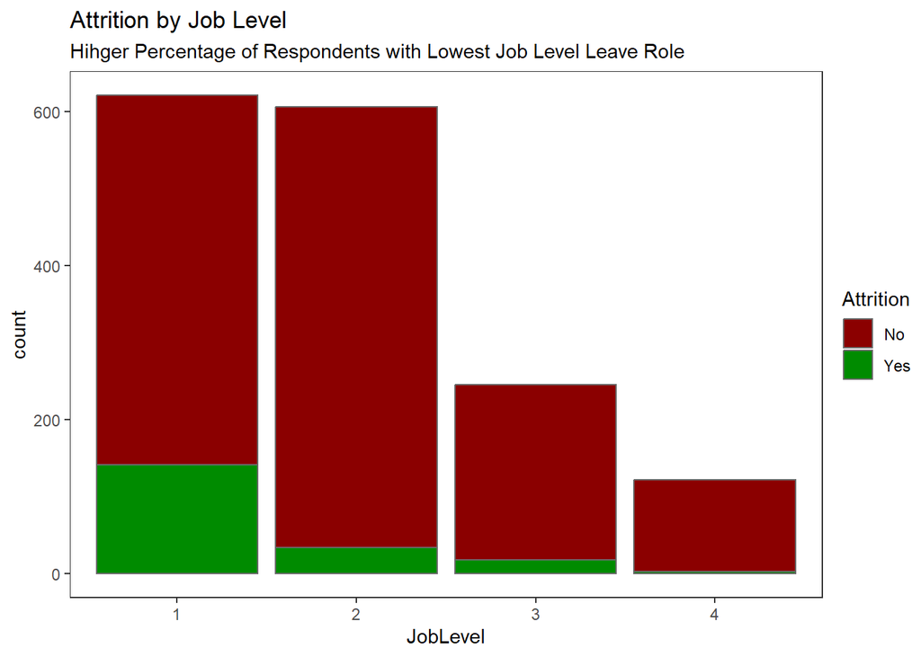

```r
ggplot(data = att, aes(x = JobLevel, fill = Attrition)) +
  geom_bar(color = "dimgrey") +
  theme_test() +
  scale_fill_manual(values = c("red4", "green4")) +
  labs(
    title = "Attrition by Job Level",
    subtitle = "Hihger Percentage of Respondents with Lowest Job Level Leave Role"
  )
```

## Initial Log Regression Models

### Dividing the Dataset

I divided the dataset with observations with NA for JobLevel removed into a training dataset and testing dataset with 80% of the observations going to former and 20% to the latter.

```r
att$EnvironmentSatisfaction <- factor(att$EnvironmentSatisfaction, ordered = FALSE)
att$JobInvolvement <- factor(att$JobInvolvement, ordered = FALSE)
att$JobLevel <- factor(att$JobLevel, ordered = FALSE)
att$JobSatisfaction <- factor(att$JobSatisfaction, ordered = FALSE)
att$PerformanceRating <- factor(att$PerformanceRating, ordered = FALSE)
att$RelationshipSatisfaction <- factor(att$RelationshipSatisfaction, ordered = FALSE)
att$WorkLifeBalance <- factor(att$WorkLifeBalance, ordered =  FALSE)
att$Education <- factor(att$Education, ordered = FALSE)
att$BusinessTravel <- factor(att$BusinessTravel, ordered = FALSE)
att$Department <- factor(att$Department, ordered = FALSE)
att$EducationField <- factor(att$EducationField, ordered = FALSE)



train_set_size <- floor(0.80 * nrow(att))
set.seed(316)
train_div<-sample(seq_len(nrow(att)), size = train_set_size)
train.att<-att[train_div, ]
test.att <- att[-train_div, ]
dim(train.att)
```

```
## [1] 1276   35
```

```r
dim(test.att)
```

```
## [1] 319  35
```

### Model Specificiation Rationales

To identify relevant independent variables to include in the logistic regression models, I focused on the Attrition visualizations and anecdotal evidence shared by healthcare workers regarding their rationales for leaving their jobs.

Specific independent variables included initially include JobRole, Age, DistanceFromHome, TotalWorkingYears, YearsAtCompany YearsInCurrentRole, YearsSinceLastPromotion, EnvironmentSatisfaction, OverTime, MartialStatus, JobInvolvement, JobSatisfaction, and JobLevel.

When considering the temporal variables, there is likely some degree of correlation between Age and TotalWorkingYears, YearsAtCompany, and YearsInCurrentRole. Given this, I will create an additional model with the non-Age temporal variables removed to see how they perform against each other.

It is possible there are associations between Age and MaritalStatus and JobLevel as well. I will pull these variables in a third model that will only include JobRole, Age, DistanceFromHome, YearsSinceLastPromotion, EnvironmentalSatisfaction, OverTime, JobInvolvement, and JobSatisfaction.

Lastly, I have been considering JobRole as a grouping variable and using fixed effects in the first three models. For the fourth model, I will explore a mixed effects model using “random” intercepts for the different role groups. Further grouping or levels is limited by the nature of this dataset.

### Models & Comparing Fit on Training Data

```r
if (!require(lme4)) install.packages("lme4")
library(lme4)
if (!require(jtools)) install.packages("jtools")
library(jtools)
if (!require(ResourceSelection)) install.packages("ResourceSelection")
```

```
## ResourceSelection 0.3-6   2023-06-27
```

```r
library(ResourceSelection)
if (!require(lmtest)) install.packages("lmtest")
library(lmtest)
reg1 <- glm(Attrition ~ JobRole+Age+DistanceFromHome+TotalWorkingYears+ YearsAtCompany + YearsInCurrentRole + YearsSinceLastPromotion + EnvironmentSatisfaction + OverTime + MaritalStatus + JobInvolvement + JobSatisfaction + JobLevel, data = train.att, family = "binomial")
summ(reg1, exp = TRUE, confint = TRUE)
```

| Observations | 1276 |
| --- | --- |
| Dependent variable | Attrition |
| Type | Generalized linear model |
| Family | binomial |
| Link | logit |

| χ²(24) | 508.11 |
| --- | --- |
| Pseudo-R² (Cragg-Uhler) | 0.63 |
| Pseudo-R² (McFadden) | 0.54 |
| AIC | 485.75 |
| BIC | 614.54 |

|  | exp(Est.) | 2.5% | 97.5% | z val. | p |
| --- | --- | --- | --- | --- | --- |
| (Intercept) | 0.00 | 0.00 | Inf | -0.02 | 0.98 |
| JobRoleNurse | 11946697.96 | 0.00 | Inf | 0.03 | 0.98 |
| JobRoleOther | 8477435.97 | 0.00 | Inf | 0.03 | 0.98 |
| JobRoleTherapist | 4926000.78 | 0.00 | Inf | 0.03 | 0.98 |
| Age | 0.91 | 0.87 | 0.95 | -4.52 | 0.00 |
| DistanceFromHome | 1.09 | 1.06 | 1.12 | 5.44 | 0.00 |
| TotalWorkingYears | 0.97 | 0.90 | 1.04 | -0.84 | 0.40 |
| YearsAtCompany | 0.86 | 0.75 | 0.99 | -2.08 | 0.04 |
| YearsInCurrentRole | 0.83 | 0.70 | 0.99 | -2.07 | 0.04 |
| YearsSinceLastPromotion | 1.27 | 1.10 | 1.46 | 3.25 | 0.00 |
| EnvironmentSatisfaction2 | 0.23 | 0.11 | 0.51 | -3.70 | 0.00 |
| EnvironmentSatisfaction3 | 0.11 | 0.05 | 0.24 | -5.67 | 0.00 |
| EnvironmentSatisfaction4 | 0.11 | 0.05 | 0.24 | -5.76 | 0.00 |
| OverTimeYes | 46.27 | 23.78 | 90.05 | 11.29 | 0.00 |
| MaritalStatusMarried | 1.71 | 0.83 | 3.54 | 1.44 | 0.15 |
| MaritalStatusSingle | 10.05 | 4.74 | 21.33 | 6.01 | 0.00 |
| JobInvolvement2 | 0.31 | 0.12 | 0.79 | -2.46 | 0.01 |
| JobInvolvement3 | 0.13 | 0.05 | 0.33 | -4.38 | 0.00 |
| JobInvolvement4 | 0.06 | 0.01 | 0.21 | -4.25 | 0.00 |
| JobSatisfaction2 | 0.53 | 0.24 | 1.21 | -1.51 | 0.13 |
| JobSatisfaction3 | 0.50 | 0.26 | 0.98 | -2.03 | 0.04 |
| JobSatisfaction4 | 0.23 | 0.11 | 0.47 | -3.95 | 0.00 |
| JobLevel2 | 0.14 | 0.06 | 0.31 | -4.89 | 0.00 |
| JobLevel3 | 0.70 | 0.24 | 2.00 | -0.67 | 0.50 |
| JobLevel4 | 1.95 | 0.20 | 19.47 | 0.57 | 0.57 |

Standard errors: MLE

```r
hoslem.test(reg1$y,predict(reg1, type = "response"))
```

```
##
##  Hosmer and Lemeshow goodness of fit (GOF) test
##
## data:  reg1$y, predict(reg1, type = "response")
## X-squared = 6.2056, df = 8, p-value = 0.6242
```

```r
reg2 <- glm(Attrition ~ JobRole+Age+DistanceFromHome + YearsSinceLastPromotion + EnvironmentSatisfaction + OverTime + MaritalStatus + JobInvolvement + JobSatisfaction + JobLevel, data = train.att, family = "binomial")
summ(reg2, exp = TRUE, confint = TRUE)
```

| Observations | 1276 |
| --- | --- |
| Dependent variable | Attrition |
| Type | Generalized linear model |
| Family | binomial |
| Link | logit |

| χ²(21) | 469.94 |
| --- | --- |
| Pseudo-R² (Cragg-Uhler) | 0.59 |
| Pseudo-R² (McFadden) | 0.50 |
| AIC | 517.92 |
| BIC | 631.25 |

|  | exp(Est.) | 2.5% | 97.5% | z val. | p |
| --- | --- | --- | --- | --- | --- |
| (Intercept) | 0.00 | 0.00 | Inf | -0.02 | 0.98 |
| JobRoleNurse | 7546941.07 | 0.00 | Inf | 0.02 | 0.98 |
| JobRoleOther | 4952349.22 | 0.00 | Inf | 0.02 | 0.98 |
| JobRoleTherapist | 3309751.64 | 0.00 | Inf | 0.02 | 0.98 |
| Age | 0.89 | 0.86 | 0.92 | -6.09 | 0.00 |
| DistanceFromHome | 1.08 | 1.05 | 1.12 | 5.33 | 0.00 |
| YearsSinceLastPromotion | 0.99 | 0.89 | 1.10 | -0.17 | 0.86 |
| EnvironmentSatisfaction2 | 0.28 | 0.13 | 0.58 | -3.45 | 0.00 |
| EnvironmentSatisfaction3 | 0.14 | 0.07 | 0.29 | -5.46 | 0.00 |
| EnvironmentSatisfaction4 | 0.14 | 0.07 | 0.27 | -5.59 | 0.00 |
| OverTimeYes | 37.63 | 20.23 | 69.98 | 11.46 | 0.00 |
| MaritalStatusMarried | 1.75 | 0.87 | 3.54 | 1.56 | 0.12 |
| MaritalStatusSingle | 8.69 | 4.22 | 17.92 | 5.86 | 0.00 |
| JobInvolvement2 | 0.30 | 0.12 | 0.74 | -2.62 | 0.01 |
| JobInvolvement3 | 0.13 | 0.05 | 0.30 | -4.67 | 0.00 |
| JobInvolvement4 | 0.05 | 0.01 | 0.17 | -4.63 | 0.00 |
| JobSatisfaction2 | 0.73 | 0.34 | 1.56 | -0.81 | 0.42 |
| JobSatisfaction3 | 0.59 | 0.31 | 1.10 | -1.66 | 0.10 |
| JobSatisfaction4 | 0.26 | 0.13 | 0.51 | -3.83 | 0.00 |
| JobLevel2 | 0.09 | 0.05 | 0.19 | -6.55 | 0.00 |
| JobLevel3 | 0.36 | 0.15 | 0.88 | -2.23 | 0.03 |
| JobLevel4 | 0.48 | 0.07 | 3.04 | -0.78 | 0.43 |

Standard errors: MLE

```r
lrtest(reg1, reg2)
```

```
## Likelihood ratio test
##
## Model 1: Attrition ~ JobRole + Age + DistanceFromHome + TotalWorkingYears +
##     YearsAtCompany + YearsInCurrentRole + YearsSinceLastPromotion +
##     EnvironmentSatisfaction + OverTime + MaritalStatus + JobInvolvement +
##     JobSatisfaction + JobLevel
## Model 2: Attrition ~ JobRole + Age + DistanceFromHome + YearsSinceLastPromotion +
##     EnvironmentSatisfaction + OverTime + MaritalStatus + JobInvolvement +
##     JobSatisfaction + JobLevel
##   #Df  LogLik Df  Chisq Pr(>Chisq)
## 1  25 -217.88
## 2  22 -236.96 -3 38.165  2.607e-08 ***
## ---
## Signif. codes:  0 '***' 0.001 '**' 0.01 '*' 0.05 '.' 0.1 ' ' 1
```

```r
hoslem.test(reg2$y, predict(reg2, type = "response"))
```

```
##
##  Hosmer and Lemeshow goodness of fit (GOF) test
##
## data:  reg2$y, predict(reg2, type = "response")
## X-squared = 3.0868, df = 8, p-value = 0.9288
```

```r
reg3 <- glm(Attrition ~ JobRole+Age+DistanceFromHome + YearsSinceLastPromotion + EnvironmentSatisfaction + OverTime + JobInvolvement + JobSatisfaction, data = train.att, family = "binomial")
summ(reg3, exp = TRUE, confint = TRUE)
```

| Observations | 1276 |
| --- | --- |
| Dependent variable | Attrition |
| Type | Generalized linear model |
| Family | binomial |
| Link | logit |

| χ²(16) | 366.50 |
| --- | --- |
| Pseudo-R² (Cragg-Uhler) | 0.48 |
| Pseudo-R² (McFadden) | 0.39 |
| AIC | 611.36 |
| BIC | 698.94 |

|  | exp(Est.) | 2.5% | 97.5% | z val. | p |
| --- | --- | --- | --- | --- | --- |
| (Intercept) | 0.00 | 0.00 | Inf | -0.02 | 0.99 |
| JobRoleNurse | 4758164.13 | 0.00 | Inf | 0.02 | 0.98 |
| JobRoleOther | 6108699.26 | 0.00 | Inf | 0.02 | 0.98 |
| JobRoleTherapist | 1128628.72 | 0.00 | Inf | 0.02 | 0.98 |
| Age | 0.87 | 0.84 | 0.90 | -8.03 | 0.00 |
| DistanceFromHome | 1.06 | 1.03 | 1.08 | 4.23 | 0.00 |
| YearsSinceLastPromotion | 0.98 | 0.89 | 1.06 | -0.55 | 0.58 |
| EnvironmentSatisfaction2 | 0.26 | 0.13 | 0.50 | -3.95 | 0.00 |
| EnvironmentSatisfaction3 | 0.18 | 0.10 | 0.34 | -5.46 | 0.00 |
| EnvironmentSatisfaction4 | 0.20 | 0.11 | 0.37 | -5.25 | 0.00 |
| OverTimeYes | 18.57 | 11.30 | 30.53 | 11.52 | 0.00 |
| JobInvolvement2 | 0.36 | 0.17 | 0.77 | -2.61 | 0.01 |
| JobInvolvement3 | 0.18 | 0.09 | 0.38 | -4.46 | 0.00 |
| JobInvolvement4 | 0.06 | 0.02 | 0.21 | -4.62 | 0.00 |
| JobSatisfaction2 | 0.72 | 0.37 | 1.41 | -0.95 | 0.34 |
| JobSatisfaction3 | 0.59 | 0.34 | 1.04 | -1.83 | 0.07 |
| JobSatisfaction4 | 0.26 | 0.14 | 0.49 | -4.23 | 0.00 |

Standard errors: MLE

```r
hoslem.test(reg3$y, predict(reg3, type = "response"))
```

```
##
##  Hosmer and Lemeshow goodness of fit (GOF) test
##
## data:  reg3$y, predict(reg3, type = "response")
## X-squared = 5.6272, df = 8, p-value = 0.6889
```

```r
reg4 <- glmer(Attrition ~ Age + DistanceFromHome + TotalWorkingYears + YearsAtCompany + YearsInCurrentRole + YearsSinceLastPromotion + EnvironmentSatisfaction + OverTime + MaritalStatus + JobInvolvement + JobSatisfaction + JobLevel + (1|JobRole), data = train.att, family = "binomial")
summ(reg4, exp = TRUE, confint = TRUE)
```

| Observations | 1276 |
| --- | --- |
| Dependent variable | Attrition |
| Type | Mixed effects generalized linear model |
| Family | binomial |
| Link | logit |

| AIC | 493.29 |
| --- | --- |
| BIC | 611.77 |
| Pseudo-R² (fixed effects) | 0.75 |
| Pseudo-R² (total) | 0.75 |

| Fixed Effects | Fixed Effects exp(Est.) | Fixed Effects 2.5% | Fixed Effects 97.5% | Fixed Effects z val. | Fixed Effects p |
| --- | --- | --- | --- | --- | --- |
| (Intercept) | 24.92 | 4.33 | 143.58 | 3.60 | 0.00 |
| Age | 0.90 | 0.86 | 0.94 | -4.70 | 0.00 |
| DistanceFromHome | 1.09 | 1.05 | 1.12 | 5.39 | 0.00 |
| TotalWorkingYears | 0.97 | 0.90 | 1.05 | -0.76 | 0.45 |
| YearsAtCompany | 0.88 | 0.78 | 1.00 | -2.04 | 0.04 |
| YearsInCurrentRole | 0.82 | 0.70 | 0.97 | -2.38 | 0.02 |
| YearsSinceLastPromotion | 1.27 | 1.10 | 1.47 | 3.33 | 0.00 |
| EnvironmentSatisfaction2 | 0.24 | 0.11 | 0.51 | -3.68 | 0.00 |
| EnvironmentSatisfaction3 | 0.12 | 0.06 | 0.25 | -5.70 | 0.00 |
| EnvironmentSatisfaction4 | 0.12 | 0.06 | 0.24 | -5.76 | 0.00 |
| OverTimeYes | 44.55 | 23.03 | 86.18 | 11.28 | 0.00 |
| MaritalStatusMarried | 1.54 | 0.74 | 3.17 | 1.16 | 0.25 |
| MaritalStatusSingle | 9.26 | 4.40 | 19.48 | 5.87 | 0.00 |
| JobInvolvement2 | 0.32 | 0.13 | 0.80 | -2.45 | 0.01 |
| JobInvolvement3 | 0.13 | 0.05 | 0.31 | -4.57 | 0.00 |
| JobInvolvement4 | 0.06 | 0.01 | 0.20 | -4.33 | 0.00 |
| JobSatisfaction2 | 0.47 | 0.21 | 1.06 | -1.82 | 0.07 |
| JobSatisfaction3 | 0.48 | 0.25 | 0.94 | -2.15 | 0.03 |
| JobSatisfaction4 | 0.22 | 0.10 | 0.45 | -4.12 | 0.00 |
| JobLevel2 | 0.14 | 0.06 | 0.30 | -4.99 | 0.00 |
| JobLevel3 | 0.52 | 0.20 | 1.37 | -1.33 | 0.18 |
| JobLevel4 | 0.49 | 0.07 | 3.46 | -0.72 | 0.47 |

| Random Effects Group | Random Effects Parameter | Random Effects Std. Dev. |
| --- | --- | --- |
| JobRole | (Intercept) | 0.13 |

| Grouping Variables Group | Grouping Variables # groups | Grouping Variables ICC |
| --- | --- | --- |
| JobRole | 4 | 0.00 |

```r
lrtest(reg1, reg2)
```

```
## Likelihood ratio test
##
## Model 1: Attrition ~ JobRole + Age + DistanceFromHome + TotalWorkingYears +
##     YearsAtCompany + YearsInCurrentRole + YearsSinceLastPromotion +
##     EnvironmentSatisfaction + OverTime + MaritalStatus + JobInvolvement +
##     JobSatisfaction + JobLevel
## Model 2: Attrition ~ JobRole + Age + DistanceFromHome + YearsSinceLastPromotion +
##     EnvironmentSatisfaction + OverTime + MaritalStatus + JobInvolvement +
##     JobSatisfaction + JobLevel
##   #Df  LogLik Df  Chisq Pr(>Chisq)
## 1  25 -217.88
## 2  22 -236.96 -3 38.165  2.607e-08 ***
## ---
## Signif. codes:  0 '***' 0.001 '**' 0.01 '*' 0.05 '.' 0.1 ' ' 1
```

```r
lrtest(reg1, reg3)
```

```
## Likelihood ratio test
##
## Model 1: Attrition ~ JobRole + Age + DistanceFromHome + TotalWorkingYears +
##     YearsAtCompany + YearsInCurrentRole + YearsSinceLastPromotion +
##     EnvironmentSatisfaction + OverTime + MaritalStatus + JobInvolvement +
##     JobSatisfaction + JobLevel
## Model 2: Attrition ~ JobRole + Age + DistanceFromHome + YearsSinceLastPromotion +
##     EnvironmentSatisfaction + OverTime + JobInvolvement + JobSatisfaction
##   #Df  LogLik Df  Chisq Pr(>Chisq)
## 1  25 -217.88
## 2  17 -288.68 -8 141.61  < 2.2e-16 ***
## ---
## Signif. codes:  0 '***' 0.001 '**' 0.01 '*' 0.05 '.' 0.1 ' ' 1
```

```r
lrtest(reg2, reg3)
```

```
## Likelihood ratio test
##
## Model 1: Attrition ~ JobRole + Age + DistanceFromHome + YearsSinceLastPromotion +
##     EnvironmentSatisfaction + OverTime + MaritalStatus + JobInvolvement +
##     JobSatisfaction + JobLevel
## Model 2: Attrition ~ JobRole + Age + DistanceFromHome + YearsSinceLastPromotion +
##     EnvironmentSatisfaction + OverTime + JobInvolvement + JobSatisfaction
##   #Df  LogLik Df  Chisq Pr(>Chisq)
## 1  22 -236.96
## 2  17 -288.68 -5 103.45  < 2.2e-16 ***
## ---
## Signif. codes:  0 '***' 0.001 '**' 0.01 '*' 0.05 '.' 0.1 ' ' 1
```

## Diagnostic Testing Reg1

I selected the reg1 model over the other three as there was evidence that one of the models outperformed the other fixed effects models. While Reg4 had the highest pseudo-R^2, reg1 had a lower AIC. Also, reg4’s ICC was so poor that I am unsure of the value of including the random intercept for JobRole.

### Residual Independence

#### Residual Plots

```r
if (!require(car)) install.packages("car")
```

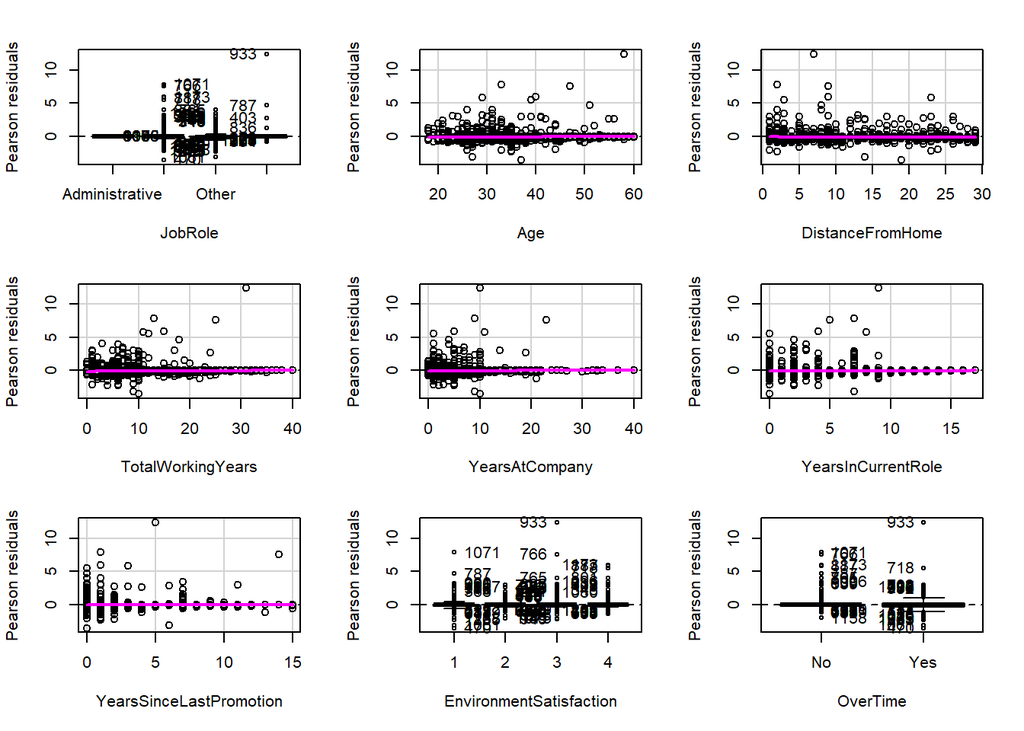

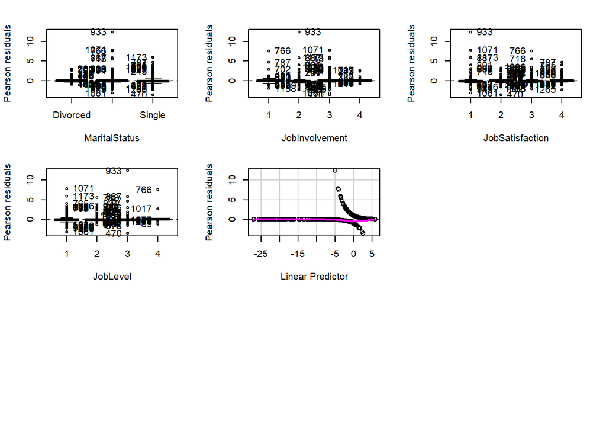

```
##                         Test stat Pr(>|Test stat|)
## JobRole
## Age                        5.4193          0.01992 *
## DistanceFromHome           0.2694          0.60376
## TotalWorkingYears          1.2127          0.27079
## YearsAtCompany             2.4149          0.12018
## YearsInCurrentRole         0.8365          0.36041
## YearsSinceLastPromotion    2.2510          0.13353
## EnvironmentSatisfaction
## OverTime
## MaritalStatus
## JobInvolvement
## JobSatisfaction
## JobLevel
## ---
## Signif. codes:  0 '***' 0.001 '**' 0.01 '*' 0.05 '.' 0.1 ' ' 1
```

```r
library(car)
residualPlots(reg1)
```

Based on the above plots, there are little to no relationships between the residuals and the continuous independent variables in reg1. Interestingly, the p-value for age is quite small. If I consider this one piece of evidence alone, I need to consider rejecting my null hypothesis that age fits the model well. I think the best course of action may be to compare two additional models, one with and one without age, alongside any additional changes that may arise with the continued assumption testing.

### Linearity of Relationships Between Continuous Ind Var and Natural Logs of Odds

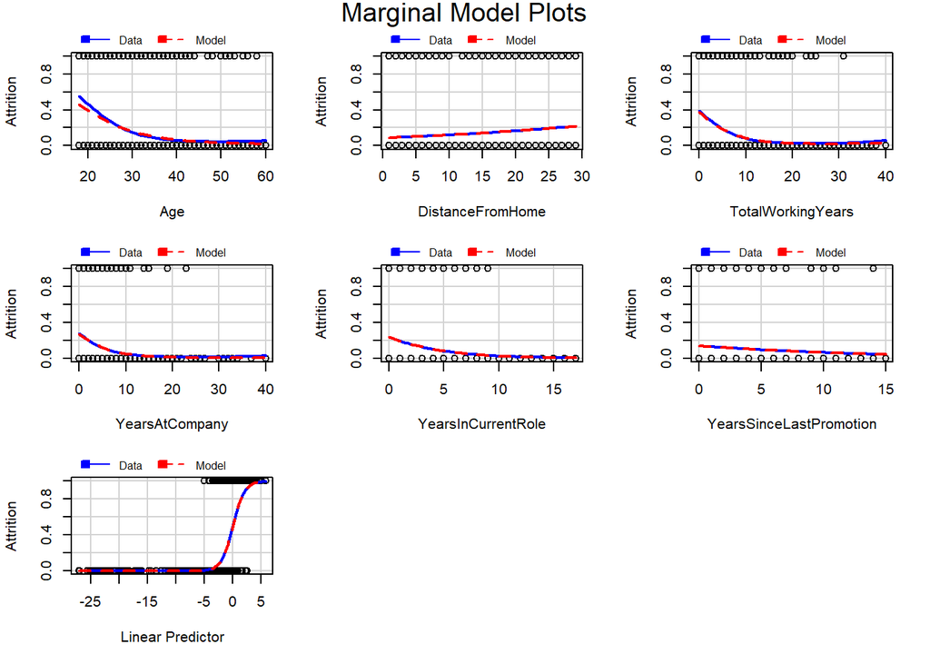

```r
marginalModelPlots(reg1)
```

The estimated relationship between independent variables and Attrition and the model predictions for the relationship is strong as evidenced by the consistent overlap of the “Data” and “Model” lines. However, these relationships deviate from being linear.

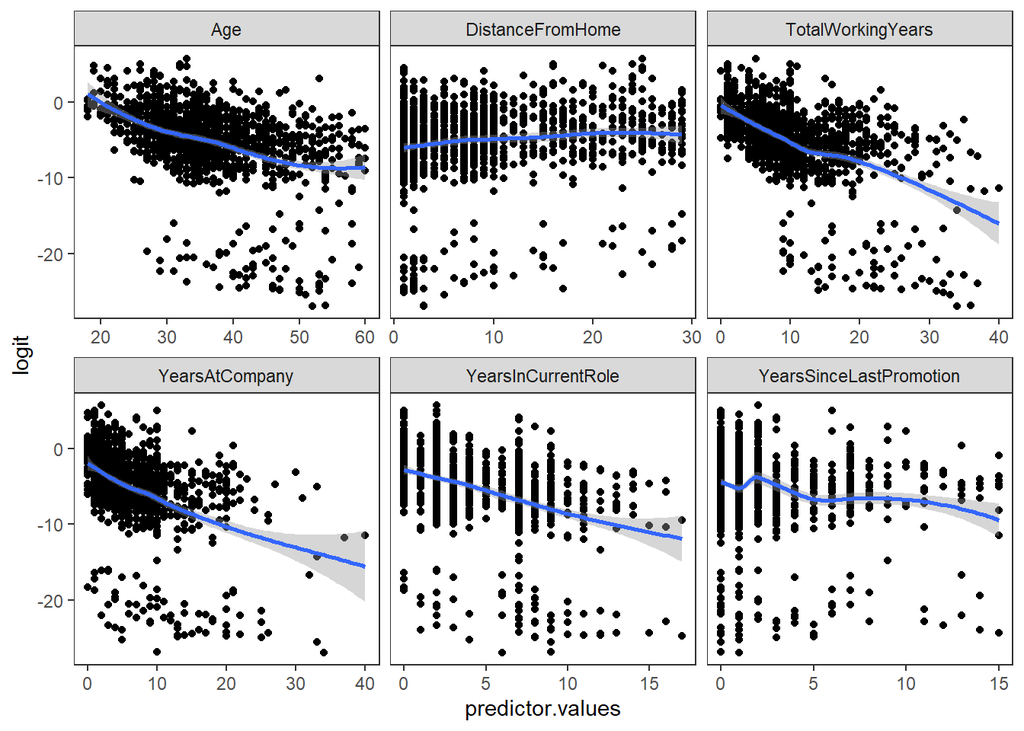

```r
linearity.check <- train.att %>%
  select(Age, DistanceFromHome, TotalWorkingYears, YearsAtCompany, YearsInCurrentRole, YearsSinceLastPromotion)
predictors <- colnames(linearity.check)
linearity.check$probabilities <- reg1$fitted.values
linearity.check <- linearity.check %>%
  mutate(logit = log(probabilities/(1 - probabilities))) %>%
  select(-probabilities) %>%
  gather(key = "predictors", value = "predictor.values", -logit)
ggplot(linearity.check, aes(y = logit, x = predictor.values)) +
  geom_point() +
  stat_smooth(method = "loess") +
  theme_test() +
  facet_wrap(~predictors, scales = "free_x")
```

I decided to assess the actual logits against the continuous independent variables. These grossly appear linear. What is more notable to me is the clustering of lower value logits. The way I visualized these plots disallows me from identifying if these reflect a specific level of a categorical independent variable.

For now, I will not plan on adding any polynomial terms or any other transformations.

### Nonadditivity

Conceptually, there could be some degree of interaction between or among these independent variables that I have not addressed. I am most concerned about an interaction between JobLevel and the temporal variables.

### Multicollineartiy

#### Correlation Matrix for Continuous Independent Variables

```r
reg1.cont.ind <- att[c("Age", "DistanceFromHome", "TotalWorkingYears", "YearsAtCompany", "YearsInCurrentRole", "YearsSinceLastPromotion")]
cor(reg1.cont.ind)
```

```
##                                Age DistanceFromHome TotalWorkingYears
## Age                     1.00000000       0.01533062        0.66155501
## DistanceFromHome        0.01533062       1.00000000        0.02189604
## TotalWorkingYears       0.66155501       0.02189604        1.00000000
## YearsAtCompany          0.29307296       0.02097758        0.61806113
## YearsInCurrentRole      0.21150996       0.02618534        0.47253042
## YearsSinceLastPromotion 0.19748605       0.01630781        0.39211092
##                         YearsAtCompany YearsInCurrentRole
## Age                         0.29307296         0.21150996
## DistanceFromHome            0.02097758         0.02618534
## TotalWorkingYears           0.61806113         0.47253042
## YearsAtCompany              1.00000000         0.77189266
## YearsInCurrentRole          0.77189266         1.00000000
## YearsSinceLastPromotion     0.61159314         0.54189737
##                         YearsSinceLastPromotion
## Age                                  0.19748605
## DistanceFromHome                     0.01630781
## TotalWorkingYears                    0.39211092
## YearsAtCompany                       0.61159314
## YearsInCurrentRole                   0.54189737
## YearsSinceLastPromotion              1.00000000
```

```r
vif(reg1)
```

```
##                             GVIF Df GVIF^(1/(2*Df))
## JobRole                 1.486018  3        1.068245
## Age                     1.991913  1        1.411351
## DistanceFromHome        1.221443  1        1.105189
## TotalWorkingYears       3.268777  1        1.807976
## YearsAtCompany          4.621883  1        2.149857
## YearsInCurrentRole      3.343026  1        1.828394
## YearsSinceLastPromotion 2.280921  1        1.510272
## EnvironmentSatisfaction 1.506820  3        1.070722
## OverTime                1.860166  1        1.363879
## MaritalStatus           1.350665  2        1.078045
## JobInvolvement          1.224774  3        1.034370
## JobSatisfaction         1.263163  3        1.039704
## JobLevel                3.942323  3        1.256875
```

As expected in the initial model specifications, there are moderate to strong relationships among the temporal independent variables. Notably, Age and TotalWorkingYears, TotalWorkingYears and YearsAtCompany, and YearsInCurrentRole and YearsAtCompany.

When considering the Variance Inflation Factor, YearsAtCompany is relatively large. I think it may be most reasonable to generate a new model by retaining all of the independent variables save for YearsAtCompany. I will also consider whether or note to include Age based on comparing two models, one with and one without Age.

### Zero Cell Count

No participants rated their JobPerformance below a 3. Fortunately, I did not include this variable in any of my models. Unfortunately, the reference Admin RoleGroup has no participants with left their job. Additionally, the Therapist RoleGroup only had 4 participants leave their job. These marked imbalances led to unrealistic exponentiated coefficients and infinite confidence intervals for the role groups. I could handle this several different ways. I can completely remove RoleGroup from future models. I could also limit the scope of the analysis to those groups with adequate numbers of observations across groups. I could also consider bootsrapping. In this case, I will plan on simply removing RoleGroup going forward.

### Outliers and Influential Observations

```r
outlierTest(reg1, labels = train.att$EmployeeID)
```

```
## No Studentized residuals with Bonferroni p < 0.05
## Largest |rstudent|:
##         rstudent unadjusted p-value Bonferroni p
## 1536328  3.30954         0.00093449           NA
```

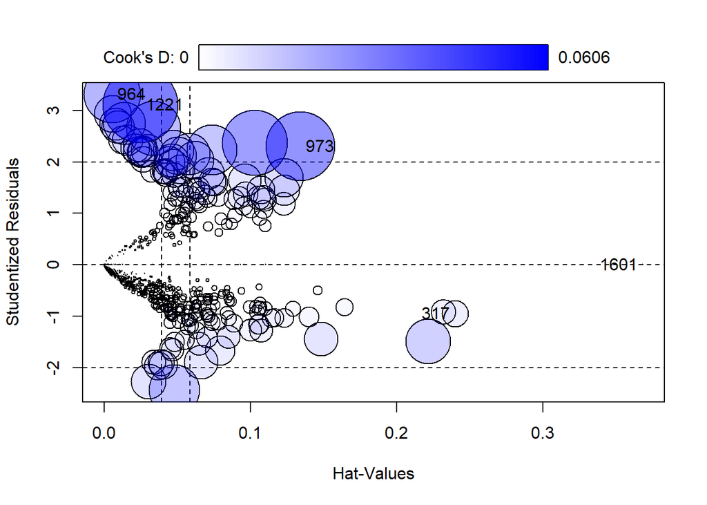

```
##            StudRes         Hat        CookD
## 1601 -0.0009942437 0.368433609 1.413778e-08
## 317  -0.9500951052 0.239881472 7.645568e-03
## 1221  3.1026592081 0.024904990 6.059328e-02
## 964   3.3095401360 0.005506775 3.446135e-02
## 973   2.2994156966 0.134289854 5.092781e-02
```

```r
influencePlot(reg1)
```

Observations 317, 964, 973, 1221, and 1601 demonstrated significant influence. I will investigate these observations by first by pulling them into their own table. I will then highlight them on scatterplots of the continuous variables.

```r
if(!require(gt)) install.packages("gt")
library(gt)
Outliers.reg1 <- train.att %>%
  filter(EmployeeID %in% c(1230043, 1536328, 1081600, 1675357, 1553672)) %>%
  select(EmployeeID, JobRole, Age, DistanceFromHome, TotalWorkingYears, YearsAtCompany, YearsInCurrentRole, YearsSinceLastPromotion, EnvironmentSatisfaction, OverTime, MaritalStatus, JobInvolvement, JobSatisfaction, JobLevel)
gt(Outliers.reg1)
```

| EmployeeID | JobRole | Age | DistanceFromHome | TotalWorkingYears | YearsAtCompany | YearsInCurrentRole | YearsSinceLastPromotion | EnvironmentSatisfaction | OverTime | MaritalStatus | JobInvolvement | JobSatisfaction | JobLevel |
| --- | --- | --- | --- | --- | --- | --- | --- | --- | --- | --- | --- | --- | --- |
| 1553672 | Administrative | 47 | 29 | 10 | 10 | 7 | 9 | 1 | Yes | Married | 3 | 2 | 3 |
| 1230043 | Nurse | 49 | 1 | 25 | 7 | 1 | 0 | 3 | Yes | Single | 2 | 3 | 4 |
| 1675357 | Nurse | 47 | 9 | 25 | 23 | 5 | 14 | 3 | No | Married | 1 | 3 | 4 |
| 1536328 | Therapist | 58 | 7 | 31 | 10 | 9 | 5 | 3 | Yes | Married | 2 | 1 | 3 |
| 1081600 | Nurse | 55 | 13 | 24 | 19 | 7 | 3 | 1 | Yes | Single | 4 | 3 | 4 |

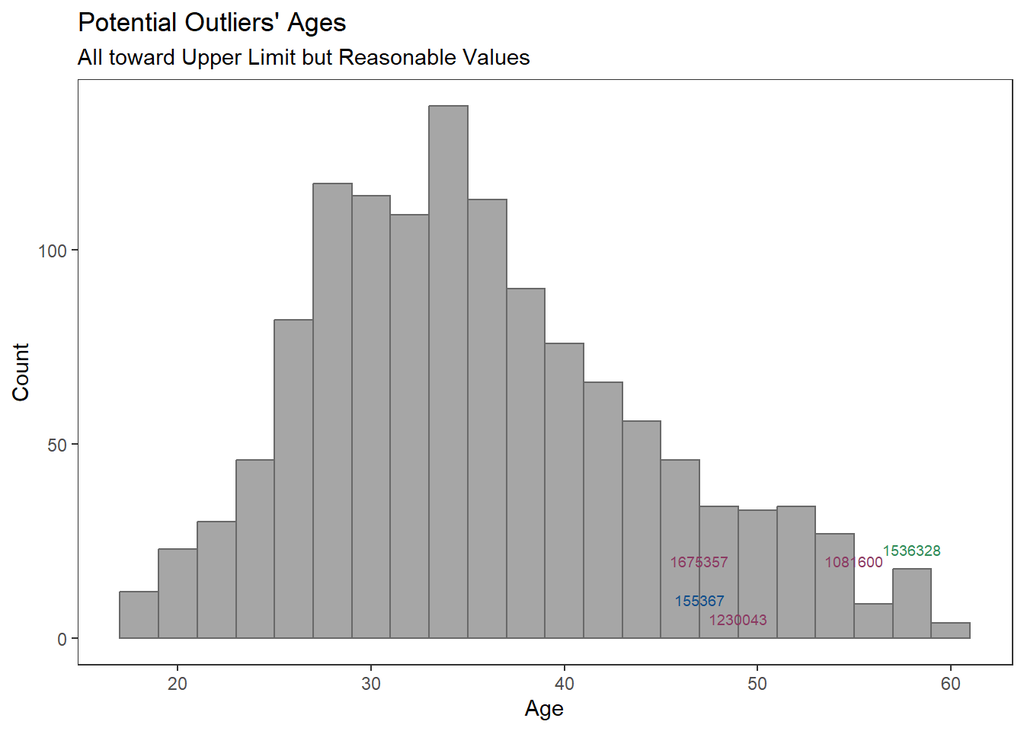

```r
ggplot(data = train.att, aes(x = Age)) +
  geom_histogram(binwidth = 2, color = "dimgrey", fill = "grey65") +
  annotate(geom = "text", x = 47, y = 10, label = "155367", color = "dodgerblue4", size = 2.5) +
  annotate(geom = "text", x = 49, y = 5, label = "1230043", color = "hotpink4", size = 2.5) +
   annotate(geom = "text", x = 47, y = 20, label = "1675357", color = "hotpink4", size = 2.5) +
   annotate(geom = "text", x = 58, y = 23, label = "1536328", color = "seagreen4", size = 2.5) +
   annotate(geom = "text", x = 55, y = 20, label = "1081600", color = "hotpink4", size = 2.5) +
  theme_test() +
  labs(
    x = "Age",
    y = "Count",
    title = "Potential Outliers' Ages",
    subtitle = "All toward Upper Limit but Reasonable Values"
  )
```

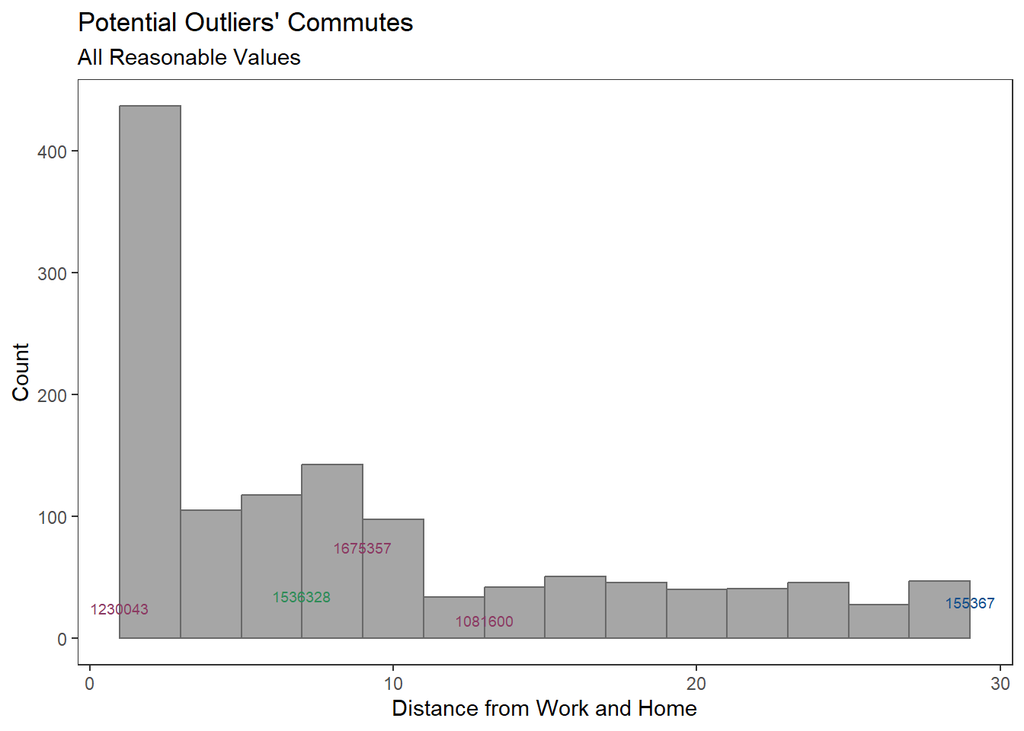

```r
ggplot(data = train.att, aes(x = DistanceFromHome)) +
  geom_histogram(binwidth = 2, color = "dimgrey", fill = "grey65") +
  annotate(geom = "text", x = 29, y = 30, label = "155367", color = "dodgerblue4", size = 2.5) +
  annotate(geom = "text", x = 1, y = 25, label = "1230043", color = "hotpink4", size = 2.5) +
   annotate(geom = "text", x = 9, y = 75, label = "1675357", color = "hotpink4", size = 2.5) +
   annotate(geom = "text", x = 7, y = 35, label = "1536328", color = "seagreen4", size = 2.5) +
   annotate(geom = "text", x = 13, y = 15, label = "1081600", color = "hotpink4", size = 2.5) +
  theme_test() +
  labs(
    x = "Distance from Work and Home",
    y = "Count",
    title = "Potential Outliers' Commutes",
    subtitle = "All Reasonable Values"
  )
```

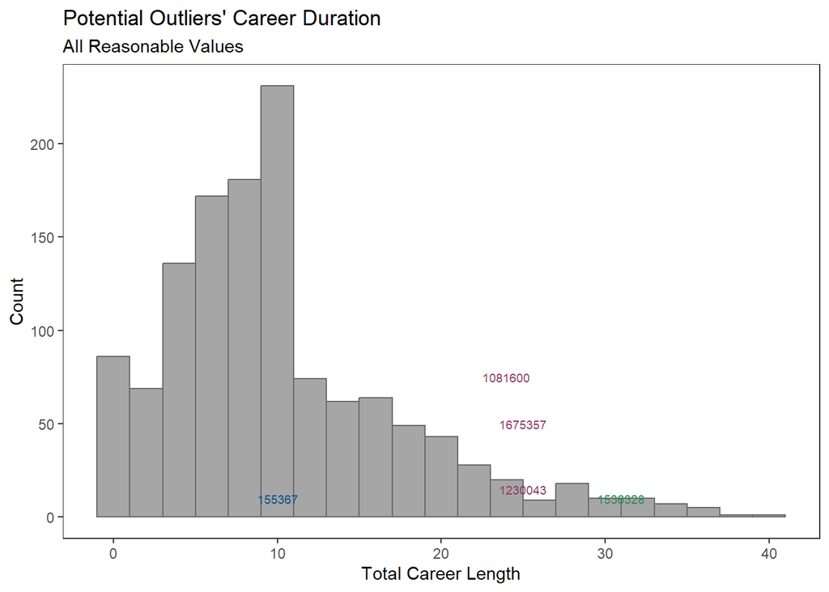

```r
ggplot(data = train.att, aes(x = TotalWorkingYears)) +
  geom_histogram(binwidth = 2, color = "dimgrey", fill = "grey65") +
  annotate(geom = "text", x = 10, y = 10, label = "155367", color = "dodgerblue4", size = 2.5) +
  annotate(geom = "text", x = 25, y = 15, label = "1230043", color = "hotpink4", size = 2.5) +
   annotate(geom = "text", x = 25, y = 50, label = "1675357", color = "hotpink4", size = 2.5) +
   annotate(geom = "text", x = 31, y = 10, label = "1536328", color = "seagreen4", size = 2.5) +
   annotate(geom = "text", x = 24, y = 75, label = "1081600", color = "hotpink4", size = 2.5) +
  theme_test() +
  labs(
    x = "Total Career Length",
    y = "Count",
    title = "Potential Outliers' Career Duration",
    subtitle = "All Reasonable Values"
    )
```

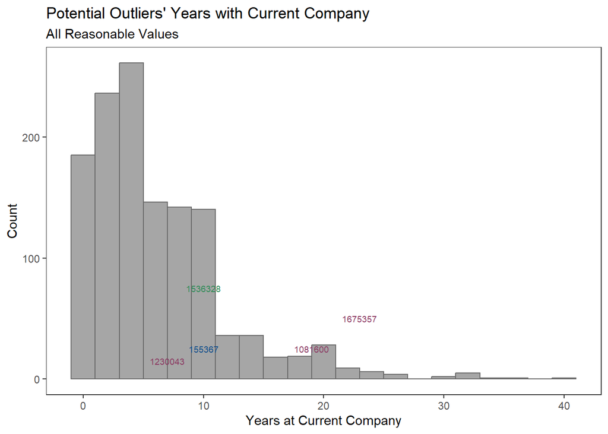

```r
ggplot(data = train.att, aes(x = YearsAtCompany)) +
  geom_histogram(binwidth = 2, color = "dimgrey", fill = "grey65") +
  annotate(geom = "text", x = 10, y = 25, label = "155367", color = "dodgerblue4", size = 2.5) +
  annotate(geom = "text", x = 7, y = 15, label = "1230043", color = "hotpink4", size = 2.5) +
   annotate(geom = "text", x = 23, y = 50, label = "1675357", color = "hotpink4", size = 2.5) +
   annotate(geom = "text", x = 10, y = 75, label = "1536328", color = "seagreen4", size = 2.5) +
   annotate(geom = "text", x = 19, y = 25, label = "1081600", color = "hotpink4", size = 2.5) +
  theme_test() +
  labs(
    x = "Years at Current Company",
    y = "Count",
    title = "Potential Outliers' Years with Current Company",
    subtitle = "All Reasonable Values"
  )
```

I do not see any clear evidence of these observations being abnormal or inaccurate. Given this, I would maintain these observations in my model. However, this model as a whole demonstrated correlations among continuous independent variables. Additionally, there were issues with linearity of the relationship between the continuous independent variables and the probability estimates. I also identified that RoleGroup lacked sufficient observations who left their jobs across the different levels. At least one new model will be specified to address these issues.

## Updated Models

Based on the diagnostic testing of assumptions for reg1, I will remove Age, YearsAtCompany, and RoleGroup.

### New Models

```r
reg5 <- glm(Attrition ~ DistanceFromHome+TotalWorkingYears + YearsInCurrentRole + YearsSinceLastPromotion + EnvironmentSatisfaction + OverTime +MaritalStatus + JobInvolvement + JobSatisfaction + JobLevel, data = train.att, family = "binomial")
summ(reg5, exp = TRUE, confint = TRUE)
```

| Observations | 1276 |
| --- | --- |
| Dependent variable | Attrition |
| Type | Generalized linear model |
| Family | binomial |
| Link | logit |

| χ²(19) | 466.30 |
| --- | --- |
| Pseudo-R² (Cragg-Uhler) | 0.59 |
| Pseudo-R² (McFadden) | 0.49 |
| AIC | 517.56 |
| BIC | 620.59 |

|  | exp(Est.) | 2.5% | 97.5% | z val. | p |
| --- | --- | --- | --- | --- | --- |
| (Intercept) | 1.94 | 0.57 | 6.66 | 1.06 | 0.29 |
| DistanceFromHome | 1.08 | 1.05 | 1.11 | 5.13 | 0.00 |
| TotalWorkingYears | 0.87 | 0.81 | 0.92 | -4.28 | 0.00 |
| YearsInCurrentRole | 0.78 | 0.69 | 0.88 | -4.10 | 0.00 |
| YearsSinceLastPromotion | 1.19 | 1.05 | 1.36 | 2.77 | 0.01 |
| EnvironmentSatisfaction2 | 0.27 | 0.13 | 0.55 | -3.63 | 0.00 |
| EnvironmentSatisfaction3 | 0.14 | 0.07 | 0.28 | -5.55 | 0.00 |
| EnvironmentSatisfaction4 | 0.14 | 0.07 | 0.28 | -5.54 | 0.00 |
| OverTimeYes | 30.87 | 17.19 | 55.44 | 11.48 | 0.00 |
| MaritalStatusMarried | 1.47 | 0.73 | 2.98 | 1.08 | 0.28 |
| MaritalStatusSingle | 8.60 | 4.25 | 17.41 | 5.98 | 0.00 |
| JobInvolvement2 | 0.30 | 0.12 | 0.71 | -2.71 | 0.01 |
| JobInvolvement3 | 0.12 | 0.05 | 0.28 | -4.85 | 0.00 |
| JobInvolvement4 | 0.06 | 0.02 | 0.19 | -4.51 | 0.00 |
| JobSatisfaction2 | 0.39 | 0.18 | 0.85 | -2.37 | 0.02 |
| JobSatisfaction3 | 0.45 | 0.24 | 0.85 | -2.44 | 0.01 |
| JobSatisfaction4 | 0.24 | 0.12 | 0.47 | -4.09 | 0.00 |
| JobLevel2 | 0.16 | 0.08 | 0.32 | -5.24 | 0.00 |
| JobLevel3 | 0.55 | 0.21 | 1.43 | -1.22 | 0.22 |
| JobLevel4 | 0.40 | 0.05 | 2.92 | -0.90 | 0.37 |

Standard errors: MLE

### Diagnostic Testing Reg 5

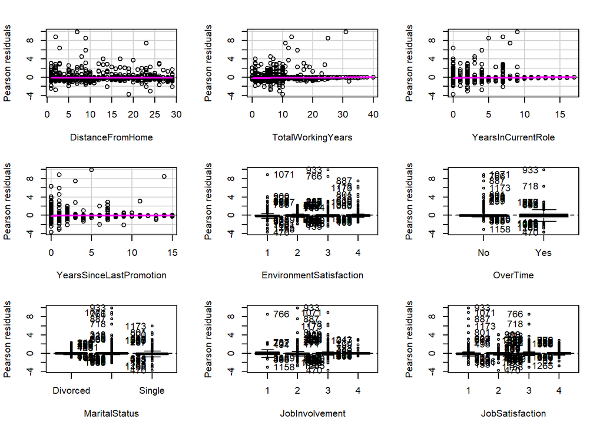

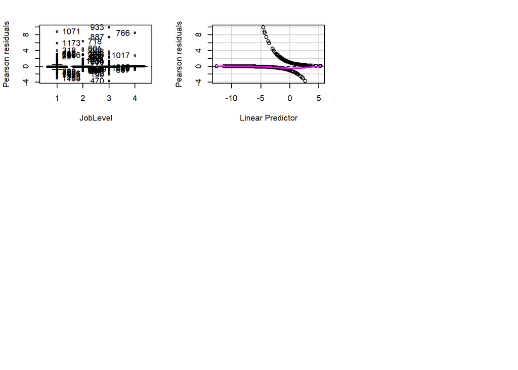

```
##                         Test stat Pr(>|Test stat|)
## DistanceFromHome           0.3710          0.54247
## TotalWorkingYears          3.8743          0.04903 *
## YearsInCurrentRole         2.4524          0.11734
## YearsSinceLastPromotion    3.2414          0.07180 .
## EnvironmentSatisfaction
## OverTime
## MaritalStatus
## JobInvolvement
## JobSatisfaction
## JobLevel
## ---
## Signif. codes:  0 '***' 0.001 '**' 0.01 '*' 0.05 '.' 0.1 ' ' 1
```

```r
residualPlots(reg5)
```

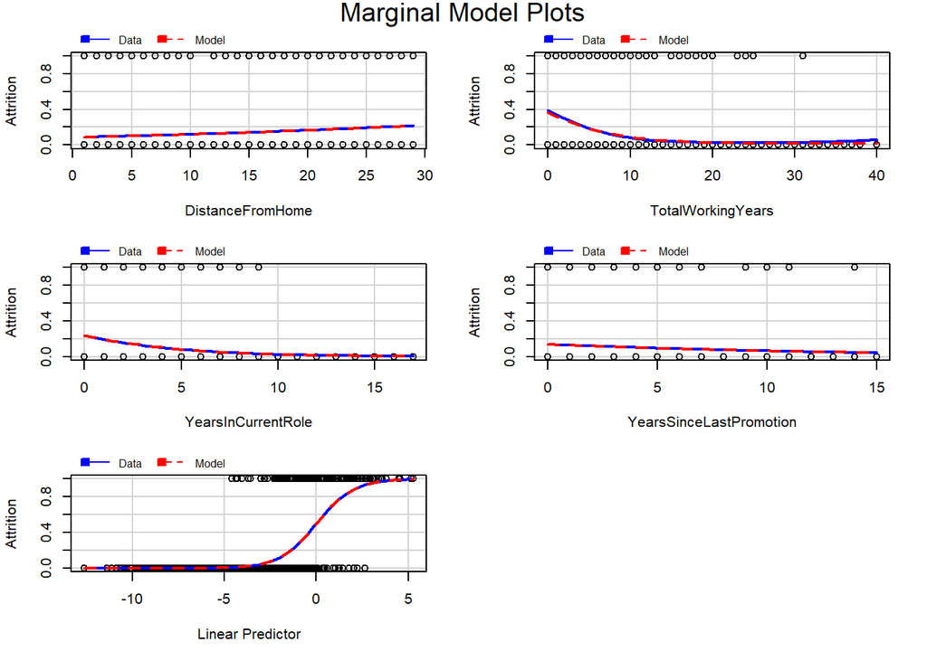

```r
marginalModelPlots(reg5)
```

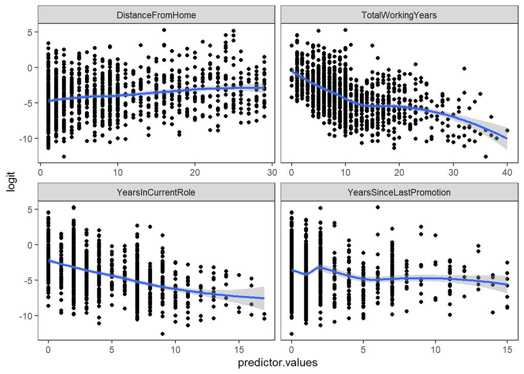

```r
linearity.check.new <-train.att %>%
  select(DistanceFromHome, TotalWorkingYears, YearsInCurrentRole, YearsSinceLastPromotion)
predictors.new <- colnames(linearity.check.new)
linearity.check.new$probabilities <- reg5$fitted.values
linearity.check.new <- linearity.check.new %>%
  mutate(logit = log(probabilities/(1 - probabilities))) %>%
  select(-probabilities) %>%
  gather(key = "predictors", value = "predictor.values", -logit)
ggplot(linearity.check.new, aes(y = logit, x = predictor.values)) +
  geom_point() +
  stat_smooth(method = "loess") +
  theme_test() +
  facet_wrap(~predictors, scales = "free_x")
```

```r
reg5.cont.ind <- att[c("DistanceFromHome", "TotalWorkingYears", "YearsInCurrentRole", "YearsSinceLastPromotion")]
cor(reg5.cont.ind)
```

```
##                         DistanceFromHome TotalWorkingYears YearsInCurrentRole
## DistanceFromHome              1.00000000        0.02189604         0.02618534
## TotalWorkingYears             0.02189604        1.00000000         0.47253042
## YearsInCurrentRole            0.02618534        0.47253042         1.00000000
## YearsSinceLastPromotion       0.01630781        0.39211092         0.54189737
##                         YearsSinceLastPromotion
## DistanceFromHome                     0.01630781
## TotalWorkingYears                    0.39211092
## YearsInCurrentRole                   0.54189737
## YearsSinceLastPromotion              1.00000000
```

```r
vif(reg5)
```

```
##                             GVIF Df GVIF^(1/(2*Df))
## DistanceFromHome        1.188650  1        1.090252
## TotalWorkingYears       2.455572  1        1.567027
## YearsInCurrentRole      1.661214  1        1.288881
## YearsSinceLastPromotion 1.782337  1        1.335042
## EnvironmentSatisfaction 1.305343  3        1.045412
## OverTime                1.565442  1        1.251176
## MaritalStatus           1.272290  2        1.062054
## JobInvolvement          1.181038  3        1.028120
## JobSatisfaction         1.199155  3        1.030732
## JobLevel                2.515903  3        1.166225
```

Similar to the issue of Age in the initial model iterations, I now have evidence that TotalWorkingYears does not fit the logistic regression model well. Additionally, TotalWorkingYears demonstrated moderate correlation with YearsInCurrentRole. I will generate an additional model with this variable removed and compare its performance against reg5.

### Reg6

```r
reg6 <- glm(Attrition ~ DistanceFromHome + YearsInCurrentRole + YearsSinceLastPromotion + EnvironmentSatisfaction + OverTime +MaritalStatus + JobInvolvement + JobSatisfaction+ JobLevel, data = train.att, family = "binomial")
summ(reg6, exp = TRUE, confint = TRUE)
```

| Observations | 1276 |
| --- | --- |
| Dependent variable | Attrition |
| Type | Generalized linear model |
| Family | binomial |
| Link | logit |

| χ²(18) | 444.55 |
| --- | --- |
| Pseudo-R² (Cragg-Uhler) | 0.56 |
| Pseudo-R² (McFadden) | 0.47 |
| AIC | 537.31 |
| BIC | 635.18 |

|  | exp(Est.) | 2.5% | 97.5% | z val. | p |
| --- | --- | --- | --- | --- | --- |
| (Intercept) | 0.82 | 0.26 | 2.54 | -0.35 | 0.73 |
| DistanceFromHome | 1.08 | 1.05 | 1.11 | 5.18 | 0.00 |
| YearsInCurrentRole | 0.74 | 0.66 | 0.83 | -5.21 | 0.00 |
| YearsSinceLastPromotion | 1.15 | 1.02 | 1.30 | 2.36 | 0.02 |
| EnvironmentSatisfaction2 | 0.30 | 0.15 | 0.60 | -3.41 | 0.00 |
| EnvironmentSatisfaction3 | 0.18 | 0.09 | 0.35 | -5.10 | 0.00 |
| EnvironmentSatisfaction4 | 0.16 | 0.08 | 0.31 | -5.32 | 0.00 |
| OverTimeYes | 25.89 | 14.79 | 45.30 | 11.40 | 0.00 |
| MaritalStatusMarried | 1.62 | 0.81 | 3.25 | 1.36 | 0.17 |
| MaritalStatusSingle | 9.19 | 4.55 | 18.54 | 6.19 | 0.00 |
| JobInvolvement2 | 0.30 | 0.13 | 0.69 | -2.83 | 0.00 |
| JobInvolvement3 | 0.12 | 0.05 | 0.28 | -5.03 | 0.00 |
| JobInvolvement4 | 0.05 | 0.02 | 0.18 | -4.71 | 0.00 |
| JobSatisfaction2 | 0.54 | 0.26 | 1.12 | -1.66 | 0.10 |
| JobSatisfaction3 | 0.55 | 0.29 | 1.01 | -1.93 | 0.05 |
| JobSatisfaction4 | 0.29 | 0.15 | 0.56 | -3.67 | 0.00 |
| JobLevel2 | 0.09 | 0.05 | 0.17 | -7.51 | 0.00 |
| JobLevel3 | 0.17 | 0.08 | 0.39 | -4.26 | 0.00 |
| JobLevel4 | 0.04 | 0.01 | 0.23 | -3.58 | 0.00 |

Standard errors: MLE

While reg5 appears to have a better model fit by AIC and pseudo-R^2, I will go forward with reg6 given my concerns over including TotalWorkingYears.

### Diagnostic Testing of Assumptions Reg6

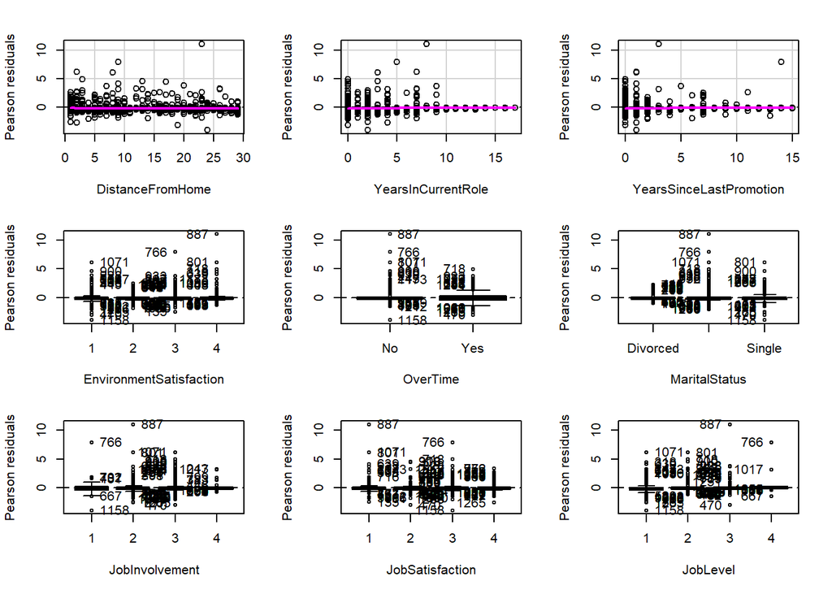

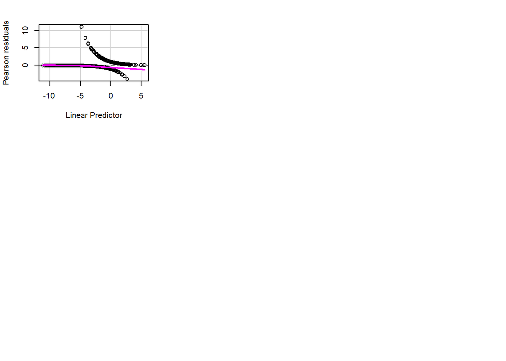

```
##                         Test stat Pr(>|Test stat|)
## DistanceFromHome           0.6781           0.4102
## YearsInCurrentRole         1.7202           0.1897
## YearsSinceLastPromotion    2.1946           0.1385
## EnvironmentSatisfaction
## OverTime
## MaritalStatus
## JobInvolvement
## JobSatisfaction
## JobLevel
```

```r
residualPlots(reg6)
```

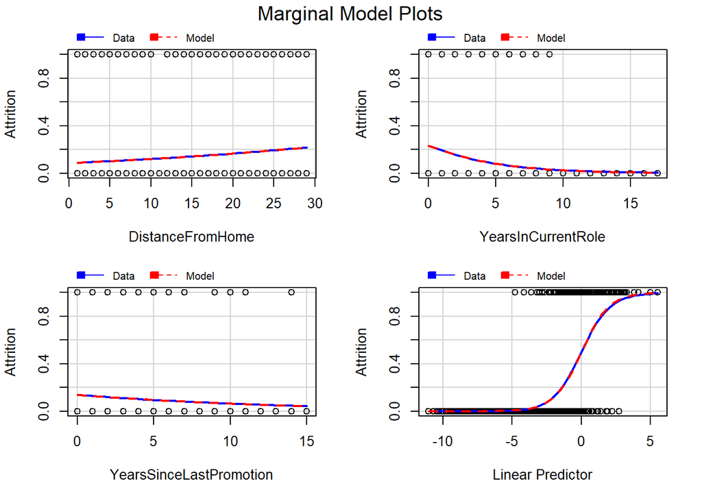

```r
marginalModelPlots(reg6)
```

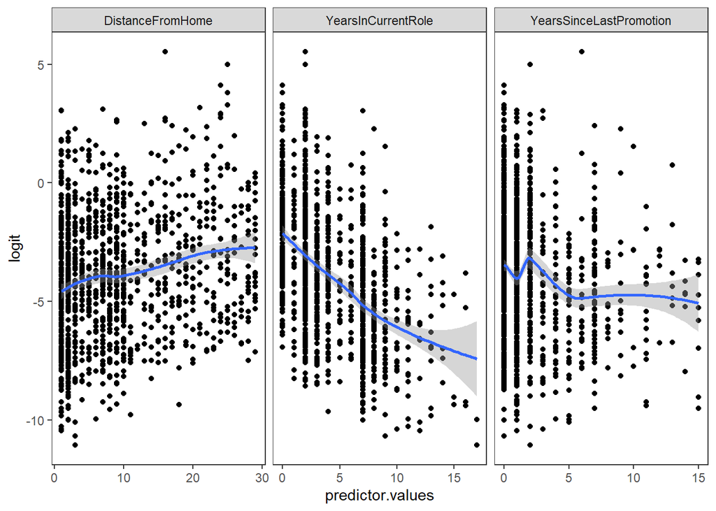

```r
linearity.check.new <-train.att %>%
  select(DistanceFromHome, YearsInCurrentRole, YearsSinceLastPromotion)
predictors.new <- colnames(linearity.check.new)
linearity.check.new$probabilities <- reg6$fitted.values
linearity.check.new <- linearity.check.new %>%
  mutate(logit = log(probabilities/(1 - probabilities))) %>%
  select(-probabilities) %>%
  gather(key = "predictors", value = "predictor.values", -logit)
ggplot(linearity.check.new, aes(y = logit, x = predictor.values)) +
  geom_point() +
  stat_smooth(method = "loess") +
  theme_test() +
  facet_wrap(~predictors, scales = "free_x")
```

```r
reg6.cont.ind <- att[c("DistanceFromHome", "YearsInCurrentRole", "YearsSinceLastPromotion")]
cor(reg6.cont.ind)
```

```
##                         DistanceFromHome YearsInCurrentRole
## DistanceFromHome              1.00000000         0.02618534
## YearsInCurrentRole            0.02618534         1.00000000
## YearsSinceLastPromotion       0.01630781         0.54189737
##                         YearsSinceLastPromotion
## DistanceFromHome                     0.01630781
## YearsInCurrentRole                   0.54189737
## YearsSinceLastPromotion              1.00000000
```

```r
vif(reg6)
```

```
##                             GVIF Df GVIF^(1/(2*Df))
## DistanceFromHome        1.173969  1        1.083499
## YearsInCurrentRole      1.564991  1        1.250996
## YearsSinceLastPromotion 1.667822  1        1.291442
## EnvironmentSatisfaction 1.260115  3        1.039286
## OverTime                1.499263  1        1.224444
## MaritalStatus           1.281736  2        1.064020
## JobInvolvement          1.194406  3        1.030051
## JobSatisfaction         1.140574  3        1.022164
## JobLevel                1.562301  3        1.077194
```

```r
outlierTest(reg6)
```

```
## No Studentized residuals with Bonferroni p < 0.05
## Largest |rstudent|:
##     rstudent unadjusted p-value Bonferroni p
## 834  3.16487          0.0015515           NA
```

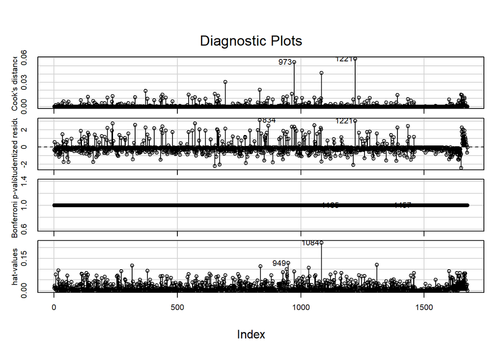

```r
influenceIndexPlot(reg6)
```

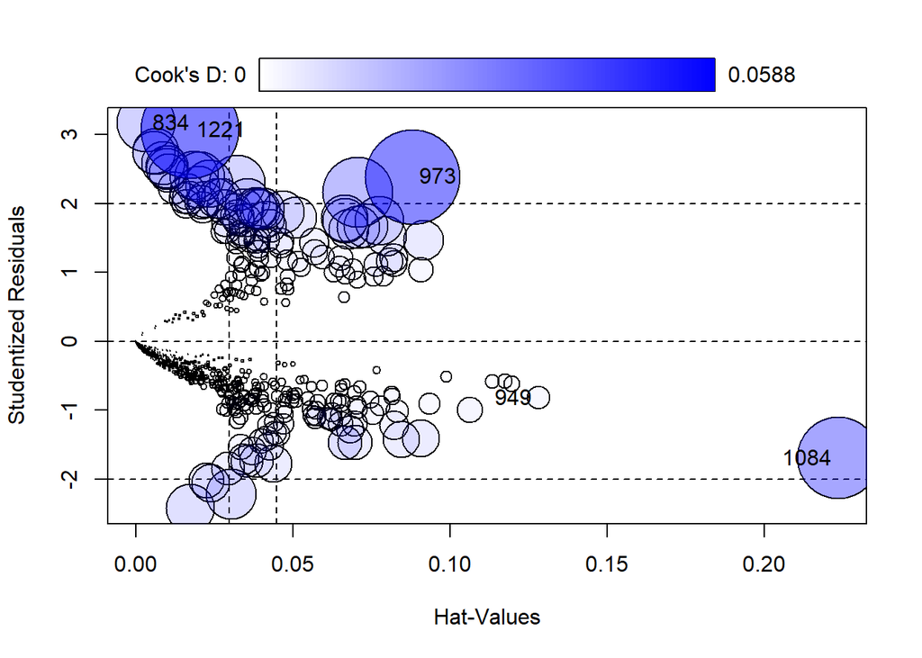

```
##         StudRes         Hat       CookD
## 949  -0.8235809 0.128093813 0.003249843
## 1084 -1.6950405 0.223436150 0.041079417
## 1221  3.0668524 0.017235456 0.058843420
## 834   3.1648699 0.003231954 0.020856246
## 973   2.3879946 0.088068161 0.054562729
```

```r
influencePlot(reg6)
```

```r
Outliers.reg6 <- train.att %>%
  filter(EmployeeID %in% c(1230043, 1385384, 1675357, 1152345, 1778989, 1081600))
gt(Outliers.reg6)
```

| EmployeeID | Age | Attrition | BusinessTravel | DailyRate | Department | DistanceFromHome | Education | EducationField | EmployeeCount | EnvironmentSatisfaction | Gender | HourlyRate | JobInvolvement | JobLevel | JobRole | JobSatisfaction | MaritalStatus | MonthlyIncome | MonthlyRate | NumCompaniesWorked | Over18 | OverTime | PercentSalaryHike | PerformanceRating | RelationshipSatisfaction | StandardHours | Shift | TotalWorkingYears | TrainingTimesLastYear | … |
| --- | --- | --- | --- | --- | --- | --- | --- | --- | --- | --- | --- | --- | --- | --- | --- | --- | --- | --- | --- | --- | --- | --- | --- | --- | --- | --- | --- | --- | --- | --- |
| 1230043 | 49 | No | Travel_Rarely | 1091 | Maternity | 1 | 2 | Technical Degree | 1 | 3 | Female | 90 | 2 | 4 | Nurse | 3 | Single | 13964 | 17810 | 7 | Y | Yes | 12 | 3 | 4 | 80 | 0 | 25 | 2 | … |
| 1385384 | 50 | No | Travel_Frequently | 333 | Maternity | 22 | 5 | Medical | 1 | 3 | Male | 88 | 1 | 4 | Administrative | 4 | Single | 14411 | 24450 | 1 | Y | Yes | 13 | 3 | 4 | 80 | 0 | 32 | 2 | … |
| 1675357 | 47 | Yes | Travel_Frequently | 1093 | Cardiology | 9 | 3 | Life Sciences | 1 | 3 | Male | 82 | 1 | 4 | Nurse | 3 | Married | 12936 | 24164 | 7 | Y | No | 11 | 3 | 3 | 80 | 0 | 25 | 3 | … |
| 1152345 | 26 | Yes | Travel_Rarely | 1146 | Cardiology | 8 | 3 | Technical Degree | 1 | 4 | Male | 38 | 2 | 2 | Nurse | 1 | Single | 5326 | 3064 | 6 | Y | No | 17 | 3 | 3 | 80 | 0 | 6 | 2 | … |
| 1778989 | 29 | Yes | Travel_Rarely | 408 | Cardiology | 23 | 1 | Life Sciences | 1 | 4 | Female | 45 | 2 | 3 | Nurse | 1 | Married | 7336 | 11162 | 1 | Y | No | 13 | 3 | 1 | 80 | 1 | 11 | 3 | … |
| 1081600 | 55 | Yes | Travel_Rarely | 267 | Cardiology | 13 | 4 | Marketing | 1 | 1 | Male | 85 | 4 | 4 | Nurse | 3 | Single | 13695 | 9277 | 6 | Y | Yes | 17 | 3 | 3 | 80 | 0 | 24 | 2 | … |

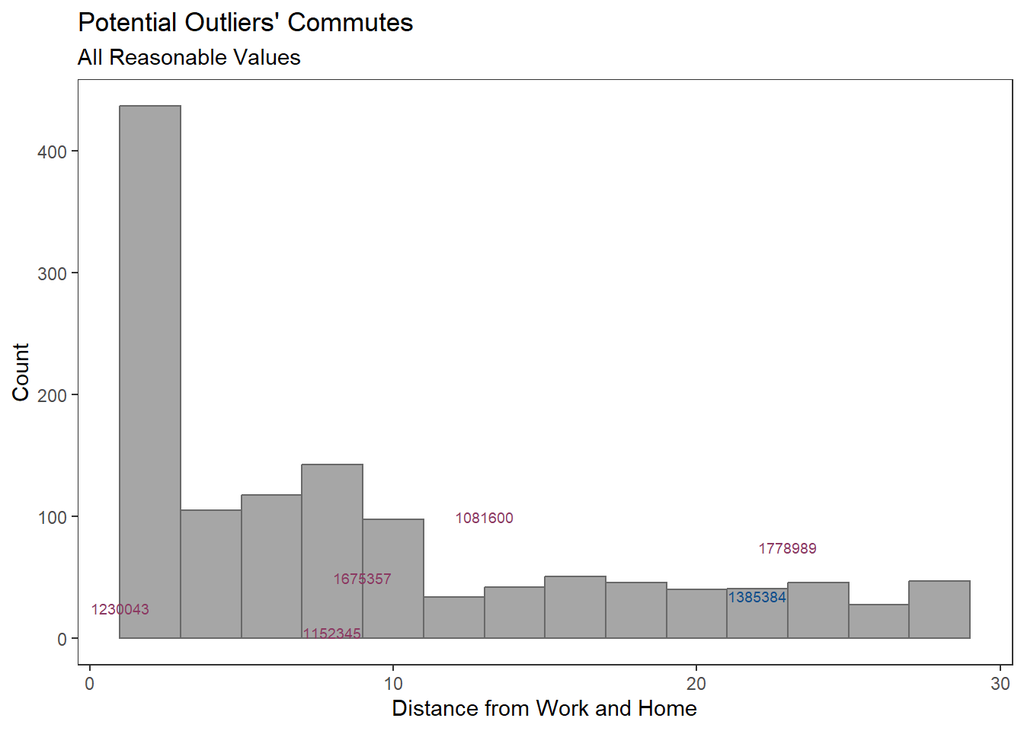

```r
ggplot(data = train.att, aes(x = DistanceFromHome)) +
  geom_histogram(binwidth = 2, color = "dimgrey", fill = "grey65") +
  annotate(geom = "text", x = 1, y = 25, label = "1230043   ", color = "hotpink4", size = 2.5) +
  annotate(geom = "text", x = 22, y = 35, label = "1385384", color = "dodgerblue4", size = 2.5) +
   annotate(geom = "text", x = 9, y = 50, label = "1675357", color = "hotpink4", size = 2.5) +
   annotate(geom = "text", x = 8, y = 5, label = "1152345", color = "hotpink4", size = 2.5) +
   annotate(geom = "text", x = 23, y = 75, label = "1778989", color = "hotpink4", size = 2.5) +
  annotate(geom = "text", x = 13, y = 100, label = "1081600", color = "hotpink4", size = 2.5) +
  theme_test() +
  labs(
    x = "Distance from Work and Home",
    y = "Count",
    title = "Potential Outliers' Commutes",
    subtitle = "All Reasonable Values"
  )
```

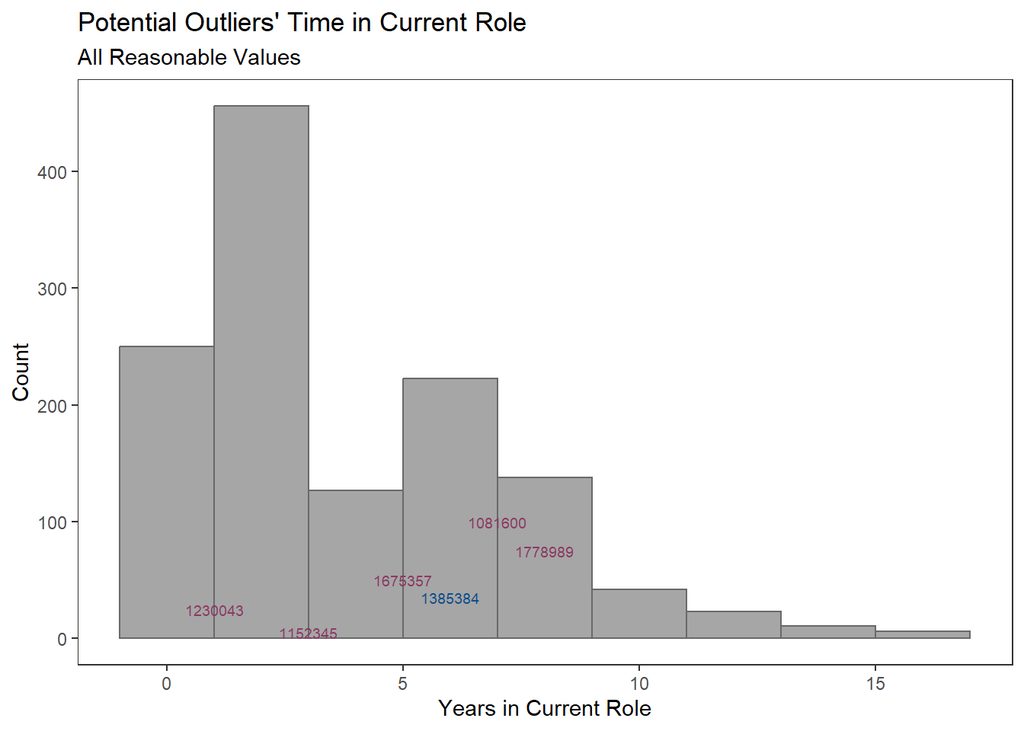

```r
ggplot(data = train.att, aes(x = YearsInCurrentRole)) +
  geom_histogram(binwidth = 2, color = "dimgrey", fill = "grey65") +
   annotate(geom = "text", x = 1, y = 25, label = "1230043  ", color = "hotpink4", size = 2.5) +
  annotate(geom = "text", x = 6, y = 35, label = "1385384", color = "dodgerblue4", size = 2.5) +
   annotate(geom = "text", x = 5, y = 50, label = "1675357", color = "hotpink4", size = 2.5) +
   annotate(geom = "text", x = 3, y = 5, label = "1152345", color = "hotpink4", size = 2.5) +
   annotate(geom = "text", x = 8, y = 75, label = "1778989", color = "hotpink4", size = 2.5) +
  annotate(geom = "text", x = 7, y = 100, label = "1081600", color = "hotpink4", size = 2.5) +
  theme_test() +
  labs(
    x = "Years in Current Role",
    y = "Count",
    title = "Potential Outliers' Time in Current Role",
    subtitle = "All Reasonable Values"
  )
```

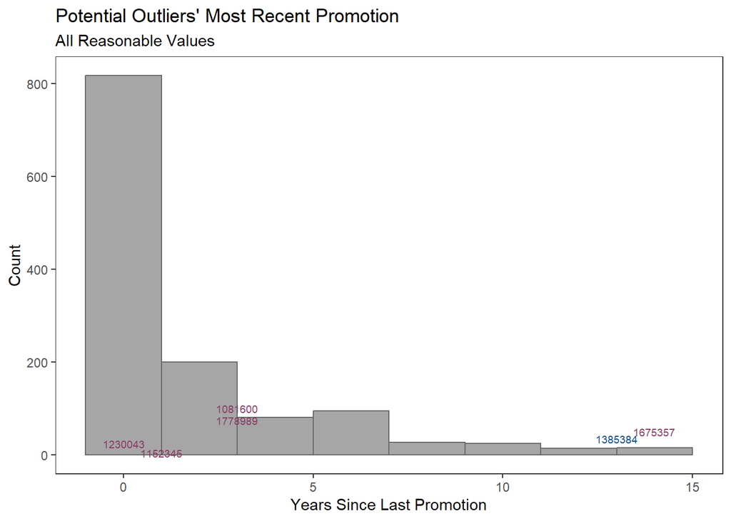

```r
ggplot(data = train.att, aes(x = YearsSinceLastPromotion)) +
  geom_histogram(binwidth = 2, color = "dimgrey", fill = "grey65") +
   annotate(geom = "text", x = 0, y = 25, label = "1230043  ", color = "hotpink4", size = 2.5) +
  annotate(geom = "text", x = 13, y = 35, label = "1385384", color = "dodgerblue4", size = 2.5) +
   annotate(geom = "text", x = 14, y = 50, label = "1675357", color = "hotpink4", size = 2.5) +
   annotate(geom = "text", x = 1, y = 5, label = "1152345", color = "hotpink4", size = 2.5) +
   annotate(geom = "text", x = 3, y = 75, label = "1778989", color = "hotpink4", size = 2.5) +
  annotate(geom = "text", x = 3, y = 100, label = "1081600", color = "hotpink4", size = 2.5) +
  theme_test() +
  labs(
    x = "Years Since Last Promotion",
    y = "Count",
    title = "Potential Outliers' Most Recent Promotion",
    subtitle = "All Reasonable Values"
  )
```

#### Reg6 Performance, Test Data

```r
if (!require(caret)) install.packages("caret")
library(caret)
test.probabilities <- predict(reg6, test.att, type = "response")
contrasts(test.att$Attrition)
```

```
##     Yes
## No    0
## Yes   1
```

```r
predicted.Attrition<- ifelse(test.probabilities > 0.5, "Yes", "No")
mean(predicted.Attrition == test.att$Attrition)
```

```
## [1] 0.8902821
```

```r
table(predicted.Attrition, test.att$Attrition)
```

```
##
## predicted.Attrition  No Yes
##                 No  267  25
##                 Yes  10  17
```

## Interpreting Results Reg6

### Sample Level

For this sample, we can look at the specific coefficients for each independent variable and, in the case of categorical and ordinal level data, the coefficients for the different levels to understand how the odds of Attrition change for individual observations.

With regard to commuting distances, an increase in Distance increases the odds of Attrition. More specifically, for every one mile increase in Distance, Attrition is predicted to change on average by 1.08 times. In other words, the odds of Attrition are predicted to increase by 8% on average when controlling for all other variables in the model.

In contrast to Distance, an increase in the time an individual has spent in their current role reduces the odds of Attrition. Specifically, for every one year increase in YearsInCurrentRole, the odds of Attrition are predicted to change by 0.74 times on average when controlling for all other variables in the model. In other words, for every one year increase in YearsInCurrentRole, the odds of leaving one’s role decrease by 26% on average.

Increasing the time since a promotion increases the odds of Attrition. In this sample, for every one year increase in YearsSinceLastPromotion is predicted to change the odds of Attrition by 1.15 on average when controlling for all the other variables in the model. This means that there is a predicted 15% average increase in the odds of Attrition.

With regard to environmental satisfaction, the odds of Attrition are predicted to change by 0.30 times on average for those who respond with level 2 as compared to those who reply with level 1 when controlling for all other variables in the model. In other words, respondents with level 2 are predicted to have odds 70% lower than those with level 1. As expected, those with even higher reported environmental satisfactor have lower odds for Attrition when controlling for all other variables.

Participating in overtime work appears to greatly impact the odds of Attrition in this sample. Those who report working overtime are predicted on average to have 25.89 times the odds of Attrition as compared to those who do not report working overtime.

Being married or single increase the odds of Attrition when compared to those who are divorced in this sample. More specifically, those who are married have odds of Attrition 1.62 times on average as compared to those who are divorced when controlling for all other variables in the model. In contrast, those who are single are predicted to have odds 9.19 times on average those who are divorced.

Increasing response levels on the question of JobInvolvement result in lower odds of Attrition as compared to the lowest level. For example, people reporting the highest job involvement have odds 95% lower than those with the lowest involvment in this sample.

Within this sample, higher levels of JobSatisfication resulted in lower odds of Attrition when compared to a level 1 rating. Levels 2, 3, and 4 had odds 0.54, 0.55, and 0.29 on average times the odds of level 1 when controlling for all other variables in the model.

Lastly, higher JobLevels demonstrated relatively lower odds of Attrition when compared to the lowest job level in this sample.

### Population Level

Instead of only looking at the exponentiated point estimate for the coefficients, we will look at the 95% confidence intervals around the exponentiated coefficients in order to gain insight into the impact of the included variables on the odds of Attrition.

From the results it appears that for each one mile increase in distance from home the odds of Attrition increase from at least 1.05 to 1.11 times on average when controlling for all other variables in the model. In other words, the odds of Attrition increase on average between 5% and 11%.

In contrast, for every one year increase in time since the last promotion, the odds for attrition change by 1.02 times to 1.30 times. In order words, the odds increase between 2% and 30% on average for every one year increase and when controlling for all other variables in the model.

Working overtime strongly predicts Attrition as evidenced by an increase in odds between 14.79 to 45.30 times when controlling for all other variables.

In contrast, the odds of Attrition change by 4.55 to 18.54 times for those who report being single as compared to those who report being divorced.

Regarding job satisfaction, only the highest level of job satisfaction appears to have a clear difference when compared to the lowest level of satisfaction. On average, having the highest job satisfaction changes the odds by 0.15 to 0.56 when controlling for all other variables.

In contrast, all job levels above the lowest appear to have lower odds of Attrition. The highest job level changes the odds of Attrition by 0.01 to 0.23 times the lowest job level when controlling for all other variables.

## References and Acknowledgements

Achim Zeileis, Torsten Hothorn (2002). Diagnostic Checking in Regression Relationships. R News 2(3), 7-10. URL https://CRAN.R-project.org/doc/Rnews/

Douglas Bates, Martin Maechler, Ben Bolker, Steve Walker (2015). Fitting Linear Mixed-Effects Models Using lme4. Journal of Statistical Software, 67(1), 1-48. doi:10.18637/jss.v067.i01.

Fox J, Weisberg S (2019). *An R Companion to Applied Regression*, Third edition. Sage, Thousand Oaks CA. https://socialsciences.mcmaster.ca/jfox/Books/Companion/.

Iannone R, Cheng J, Schloerke B, Hughes E, Lauer A, Seo J (2024). *gt: Easily Create Presentation-Ready Display Tables*. R package version 0.10.1, https://CRAN.R-project.org/package=gt.

Kuhn, M. (2008). Building Predictive Models in R Using the caret Package. Journal of Statistical Software, 28(5), 1–26. https://doi.org/10.18637/jss.v028.i05

Long JA (2022). *jtools: Analysis and Presentation of Social Scientific Data*. R package version 2.2.0, https://cran.r-project.org/package=jtools.

Miller, J.M. (2023). Employee attrition for healthcare. Retrieved April 20, 2024 from  
https://www.kaggle.com/datasets/jpmiller/employee-attrition-for-healthcare.

Posit team (2024). RStudio: Integrated Development Environment for R. Posit Software, PBC, Boston, MA. URL http://www.posit.co/.

R Core Team (2024). *R: A Language and Environment for Statistical Computing*. R Foundation for Statistical Computing, Vienna, Austria. https://www.R-project.org/.

Sjoberg DD, Whiting K, Curry M, Lavery JA, Larmarange J. Reproducible summary tables with the gtsummary package. The R Journal 2021;13:570–80. https://doi.org/10.32614/RJ-2021-053.

Stef van Buuren, Karin Groothuis-Oudshoorn (2011). mice: Multivariate Imputation by Chained Equations in R. Journal of Statistical Software, 45(3), 1-67. DOI 10.18637/jss.v045.i03.

U.S. Bureau of Labor Statistics. (2024, April 17). Healthcare occupations. U.S. Bureau of Labor Statistics. https://www.bls.gov/ooh/healthcare/home.htm

Wickham H, Averick M, Bryan J, Chang W, McGowan LD, François R, Grolemund G, Hayes A, Henry L, Hester J, Kuhn M, Pedersen TL, Miller E, Bache SM, Müller K, Ooms J, Robinson D, Seidel DP, Spinu V, Takahashi K, Vaughan D, Wilke C, Woo K, Yutani H (2019). “Welcome to the tidyverse.” *Journal of Open Source Software*, *4*(43), 1686. doi:10.21105/joss.01686 https://doi.org/10.21105/joss.01686.